# Outliers And Summaries

# Goal

This notebook shows how to use visualization and summaries to find unusual values.

Outliers are not automatically errors. They are values worth investigating.

# Analytic Questions

We will ask:

- What does the distribution of daily energy intake look like in the teaching file?
- Which values are unusually high by a simple IQR rule?
- How do we visualize outliers without letting them dominate the whole analysis?

# Load Data

```r
nhanes_path <- "data/real/nhanes_2021_2023_analysis.csv"

nhanes <- read_csv(nhanes_path, show_col_types = FALSE)

nhanes |>
  glimpse()
```

```
Rows: 11,933
Columns: 57
$ respondent_id                 <dbl> 130378, 130379, 130380, 130381, 130382, …
$ release_cycle                 <dbl> 12, 12, 12, 12, 12, 12, 12, 12, 12, 12, …
$ interview_exam_status         <chr> "interviewed_and_examined", "interviewed…
$ gender                        <chr> "male", "male", "female", "female", "mal…
$ age_years                     <dbl> 43, 66, 44, 5, 2, 3, 43, 65, 34, 68, 27,…
$ age_months_screening_0_to_24  <dbl> NA, NA, NA, NA, NA, NA, NA, NA, NA, NA, …
$ age_group                     <chr> "30-44", "65-79", "30-44", "0-17", "0-17…
$ race_ethnicity                <chr> "Non-Hispanic Asian", "Non-Hispanic Whit…
$ exam_period                   <chr> "May-October", "May-October", "November-…
$ born_in_us                    <chr> "no", "yes", "no", "yes", "yes", "yes", …
$ years_in_us_category          <chr> "20 years or more", NA, "20 years or mor…
$ education_adults_20_plus      <chr> "College graduate or above", "College gr…
$ marital_status_adults_20_plus <chr> "Married/living with partner", "Married/…
```

[output cut: 44 more lines]

# Prepare Dietary Data

```r
diet <- nhanes |>
  filter(!is.na(mean_daily_energy_kcal))

diet |>
  select(respondent_id, age_years, gender, age_group, mean_daily_energy_kcal) |>
  head()
```

```
# A tibble: 6 × 5
  respondent_id age_years gender age_group mean_daily_energy_kcal
          <dbl>     <dbl> <chr>  <chr>                      <dbl>
1        130378        43 male   30-44                      1390
2        130379        66 male   65-79                      2484.
3        130380        44 female 30-44                      1735
4        130381         5 female 0-17                       1372
5        130382         2 male   0-17                       1144.
6        130386        34 male   30-44                      2133
```

The dietary summaries are simple averages over available recall days. They are for exploratory teaching examples, not formal usual-intake estimation.

# Plot The Distribution

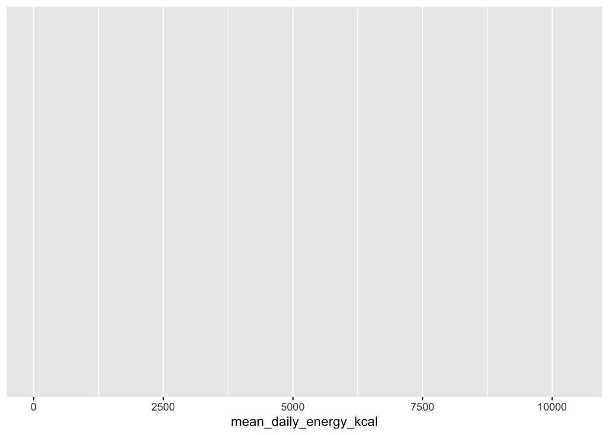

```r
p1 <- ggplot(
  diet,
  aes(x = mean_daily_energy_kcal)
)

p1
```

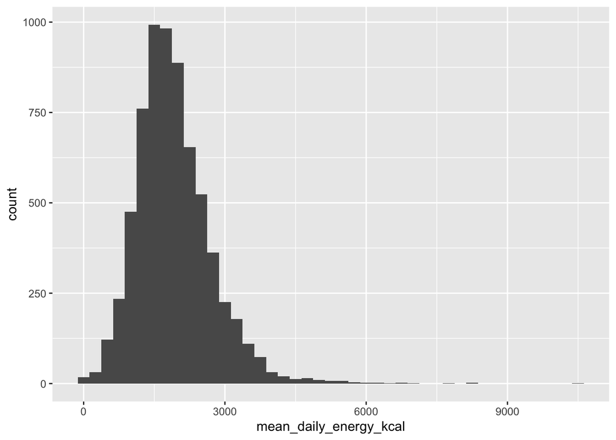

```r
p2 <- p1 +
  geom_histogram(binwidth = 250)

p2
```

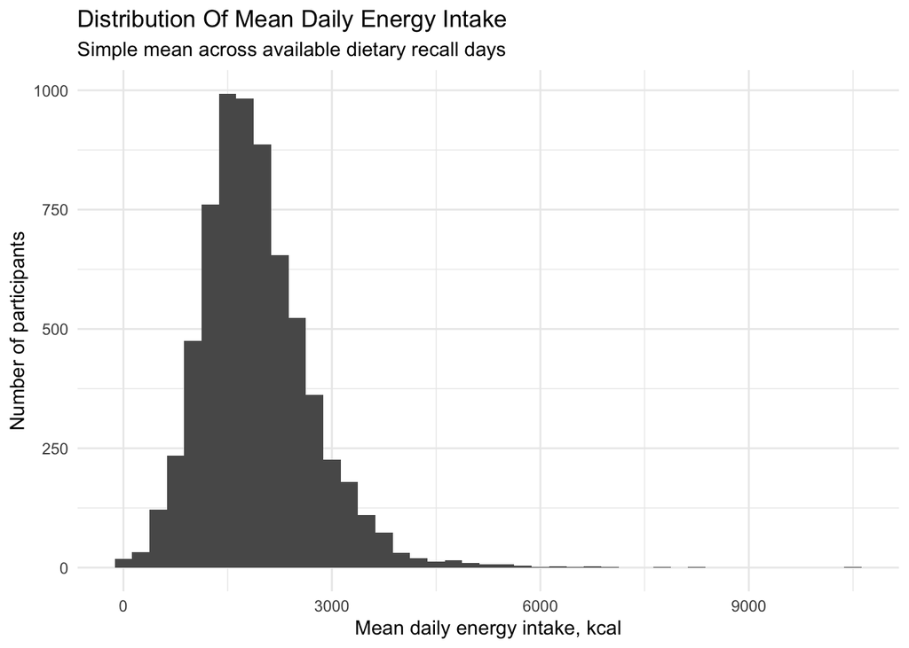

```r
p3 <- p2 +
  labs(
    title = "Distribution Of Mean Daily Energy Intake",
    subtitle = "Simple mean across available dietary recall days",
    x = "Mean daily energy intake, kcal",
    y = "Number of participants"
  ) +
  theme_minimal()

p3
```

# Calculate A Simple Outlier Rule

Use the common 1.5 IQR rule as a screening tool.

```r
energy_cutoffs <- diet |>
  summarize(
    q1 = quantile(mean_daily_energy_kcal, 0.25),
    q3 = quantile(mean_daily_energy_kcal, 0.75),
    iqr = IQR(mean_daily_energy_kcal),
    lower_cutoff = q1 - 1.5 * iqr,
    upper_cutoff = q3 + 1.5 * iqr
  )

energy_cutoffs
```

```
# A tibble: 1 × 5
     q1    q3   iqr lower_cutoff upper_cutoff
  <dbl> <dbl> <dbl>        <dbl>        <dbl>
1 1389. 2327.  938.        -18.9        3735.
```

We calculate both cutoffs, but today’s question focuses on unusually high energy intake, so we flag only values above the upper cutoff.

```r
diet_flagged <- diet |>
  mutate(
    high_energy_outlier = mean_daily_energy_kcal > energy_cutoffs$upper_cutoff
  )

diet_flagged |>
  count(high_energy_outlier)
```

```
# A tibble: 2 × 2
  high_energy_outlier     n
  <lgl>               <int>
1 FALSE                6593
2 TRUE                  159
```

# Highlight Flagged High Values

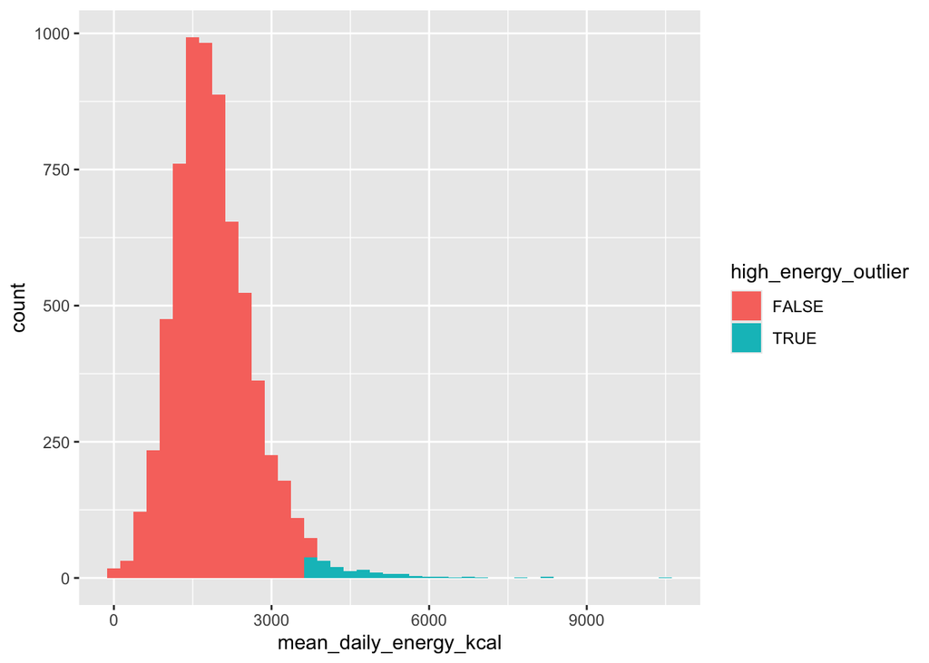

```r
p1 <- ggplot(
  diet_flagged,
  aes(
    x = mean_daily_energy_kcal,
    fill = high_energy_outlier
  )
) +
  geom_histogram(binwidth = 250)

p1
```

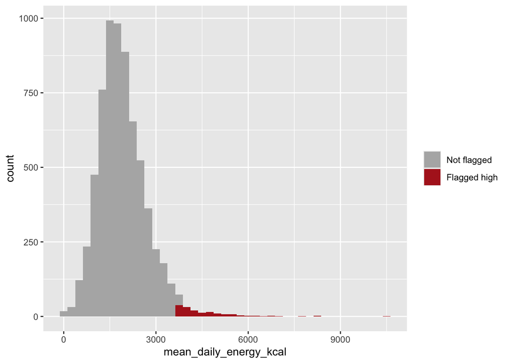

```r
p2 <- p1 +
  scale_fill_manual(
    values = c("TRUE" = "firebrick", "FALSE" = "gray70"),
    labels = c("FALSE" = "Not flagged", "TRUE" = "Flagged high"),
    name = NULL
  )

p2
```

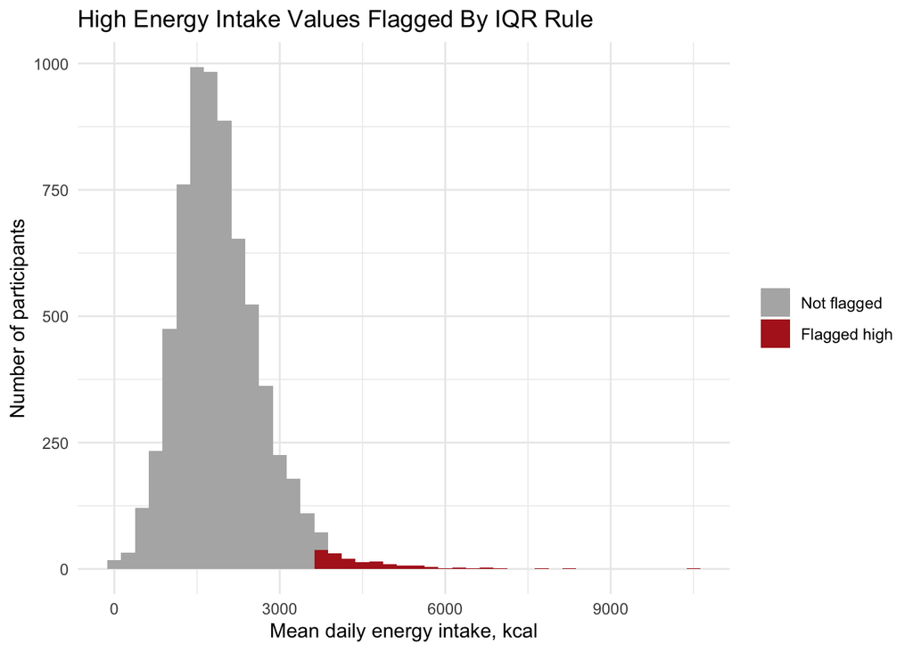

```r
p3 <- p2 +
  labs(
    title = "High Energy Intake Values Flagged By IQR Rule",
    x = "Mean daily energy intake, kcal",
    y = "Number of participants"
  ) +
  theme_minimal()

p3
```

# Inspect Flagged Rows

```r
diet_flagged |>
  filter(high_energy_outlier) |>
  select(respondent_id, age_years, gender, age_group, dietary_days, mean_daily_energy_kcal) |>
  arrange(desc(mean_daily_energy_kcal)) |>
  head(10)
```

```
# A tibble: 10 × 6
   respondent_id age_years gender age_group dietary_days mean_daily_energy_kcal
           <dbl>     <dbl> <chr>  <chr>            <dbl>                  <dbl>
 1        139174        27 male   18-29                1                 10446
 2        135541        68 male   65-79                1                  8179
 3        135173        58 male   45-64                2                  8135
 4        138180        18 male   18-29                1                  7645
 5        136473        60 male   45-64                2                  6977
 6        130904        28 male   18-29                1                  6723
 7        139856        35 male   30-44                1                  6657
 8        131077        47 male   45-64                2                  6650.
 9        130801        56 male   45-64                2                  6502.
10        131498        41 female 30-44                2                  6306.
```

# Optional Preview: Compare With A Box Plot

The main Day 2 goal is one-variable EDA. This box plot previews Day 3, when we compare distributions across groups.

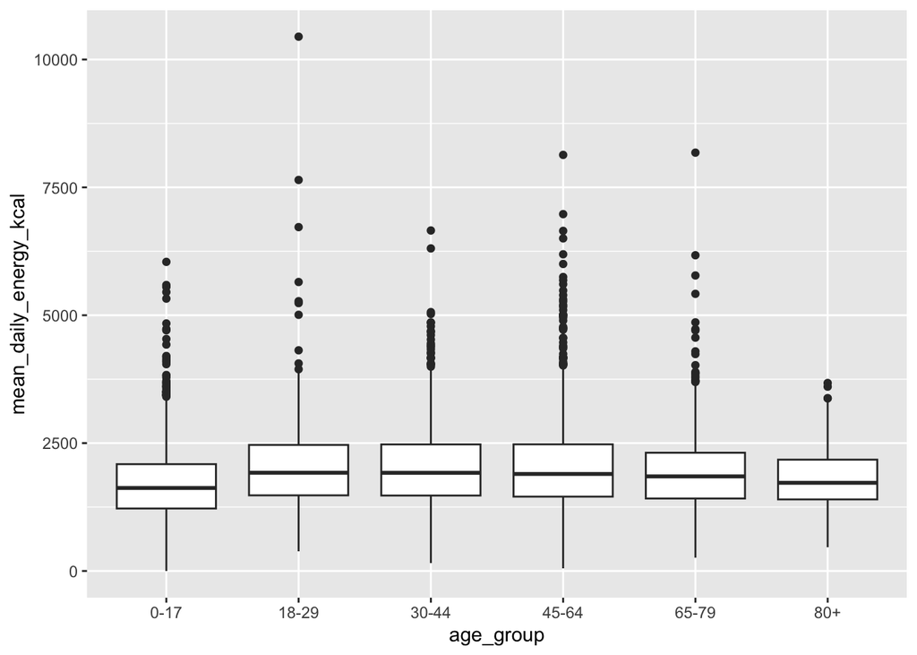

```r
p1 <- ggplot(
  diet,
  aes(x = age_group, y = mean_daily_energy_kcal)
) +
  geom_boxplot()

p1
```

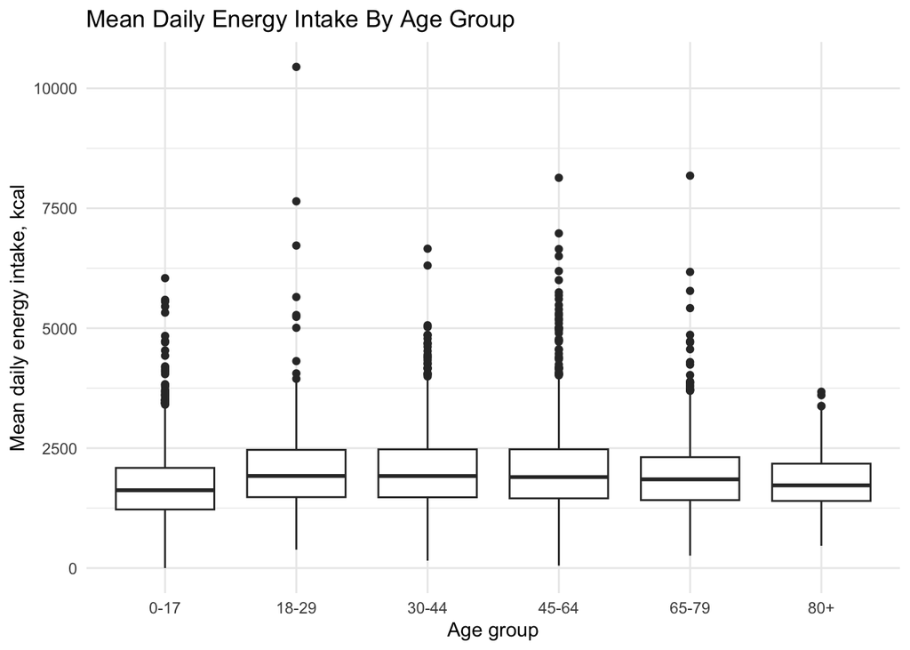

```r
p2 <- p1 +
  labs(
    title = "Mean Daily Energy Intake By Age Group",
    x = "Age group",
    y = "Mean daily energy intake, kcal"
  ) +
  theme_minimal()

p2
```

# Takeaways

- Outliers can be errors, true rare values, or signs that the variable needs context.
- A rule like 1.5 IQR is a screening tool, not a final judgment.
- Visualization helps show whether unusual values are isolated or part of a tail.
- Inspect the rows behind surprising values before deciding what to do.